# Homework 5

Modified

We 2023-09-13 15:55

Due

Mo 2025-09-29 8:00

Do the following in engineering format.

1. The walls of a refrigerator are typically constructed by sandwiching a layer of insulation between sheet metal panels. Consider a wall made from fiberglass insulation of thermal conductivity $k_i=0.046 \frac{W}{mK}$ and thickness $L_i = 50 mm$ and steel panels, each of thermal conductivity $k_p = 60 \frac{W}{mK}$ and thickness $L_p=3 mm$. If the wall separates refrigerated air at $T_{\infty,i}=4^\circ C$ from ambient air at $T_{\infty,o}=25 ^\circ C$, what is the heat gain per unit surface area? Coefficients associated with natural convection at the inner and outer surfaces may be approximated as $h_i = h_o = 5 \frac{W}{m^2 K}$.

   *Answer:* $14.1 \frac{W}{m^2}$
2. The composite wall of an oven consists of three materials, two of which are of known thermal conductivity, $k_A=20 \frac{W}{mK}$ and $k_C=50 \frac{W}{mK}$, and known thickness, $L_A = 0.30 m$ and $L_C = 0.15 m$. The third material, B, which is sandwiched between materials A and C, is of known thickness, $L_B = 0.15 m$, but unknown thermal conductivity $k_B$. Under steady-state operating conditions, measurements reveal an outer surface temperature of $T_{s,o}=20^\circ C$, an inner surface temperature of $T_{s,i} = 600 ^\circ C$, and an oven air temperature of $T_{\infty}= 800^\circ C$. The inside convection coefficient $h$ is known to be $25 \frac{W}{m^2 K}$. What is the value of $k_B$?

   *Answer:* $1.53 \frac{W}{m K}$
3. Two stainless steel plates $10 mm$ thick are subjected to a contact pressure of $1 bar$ under vacuum conditions for which there is an overall temperature drop of $100^\circ C$ across the plates. What is the heat flux through the plates? What is the temperature drop across the contact plane?

   *Answers:* $3.63 \times 10^4 \frac{W}{m^2}$, $56.3 ^\circ C$
4. For the composite wall shown below, the length of section A and B are $L_A = 10 mm$ and $L_B = 20 mm$. The total height and the height of section C are $H = 20 mm$ and $H_C = 12 mm$. The temperature at $T_1$ and $T_2$ are $60 ^\circ$ and $20 ^\circ$, respectively. If the thermal conductivity of sections A, B, and C are $k_A = 1.2 \frac{W}{m K}$, $k_B = 2.5 \frac{W}{m K}$, and $k_C = 3.7 \frac{W}{m K}$, what is the heat rate per unit wall depth?

   Figure 1: Wall Diagram

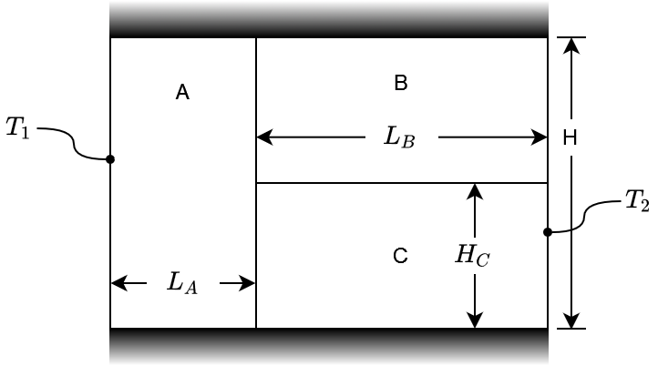

   *Answer:* $55.0 \frac{W}{m}$

Homework submission should be made on [Canvas](https://canvas.latech.edu).